# Education for Employment

### Overview

Education For Employment (EFE) is the leading nonprofit that trains youth and links them to jobs across the Middle East and North Africa (MENA). This pivotal region is the hardest place on the planet for youth to get their first job – they are three times more likely to be unemployed than older adults.

EFE is interested in the effectiveness of their programs, particularly whether graduates find stable employment. We have data on about 7,000 participants in almost 500 program cohorts spread across 8 countries. Participants bring diverse skills, interests, and backgrounds. Programs employ a variety of training models and placement policies. How well are different programs working, and for whom?

### Data

EFE has an Salesforce database that houses all information about the organization’s programs, participants, and job placement and retention outcomes. The datasets used in this project include:

- Participant demographics (program applications)
- Pre- and post- program participation surveys (job skills, confidence,…)
- Employment information at 3-month intervals for up to 2 years

### Data Pre-Processing

Initially, the data exports from Salesforce were pre-processed in the following ways:

- To protect PII, Contact ID, Program Name, Company Name, and Class Name were all anonymized by replacing the actual IDs/Names with new, numerical IDs. Lookup tables were sent to EFE so that they can bring the actual values back in if company, program, or class name are significant in the analysis.
- The applications dataset sometimes contained more than one application per person. Information from previous applications was deemed to be not as important, so only the most recent application was retained, and a new column containing the number of applications each person submitted was added. The application data was then joined to the contact data to create a more complete profile for each program participant.
- Any individuals who were not present in the Employment Status Check dataset were removed from the contact and pre/post survey datasets.

The preprocessing script [can be viewed on GitHub](https://github.com/DataKind-DC/EducationForEmployment/blob/main/PreProcessing.R) so that the deidentification steps can be reproduced with new data exports.

### Feature Engineering

#### Job Placement

| months_job | pl_grad | pl_3 | pl_6 | pl_9 | pl_12 | pl_12_data |
| --- | --- | --- | --- | --- | --- | --- |
| Placed at Graduation | 1 | 1 | 1 | 1 | 1 | 1 |
| Placed at 3 Months | 0 | 1 | 1 | 1 | 1 | 1 |
| Placed at 6 Months | 0 | 0 | 1 | 1 | 1 | 1 |
| Placed at 9 Months | 0 | 0 | 0 | 1 | 1 | 1 |
| Placed at 12 Months | 0 | 0 | 0 | 0 | 1 | 1 |
| Not Placed | 0 | 0 | 0 | 0 | 0 | 1 |
| Not Reached at 12 Months | 0 | 0 | 0 | 0 | 0 | 0 |

#### Job Retention

| Retention at 6 Months | Participants |
| --- | --- |
| Data Not Available | 2752 |
| No | 1388 |
| Yes | 1264 |

#### Employment Status Check Surveys

The analysis is initially interested in retention at 6 months; therefore the employment status check data will be filtered to contain only the 6 month surveys, and those survey responses can be joined to the participant contact information retaining a 1:1 relationship.

#### Pre and Post Training Surveys

The pre and post training surveys contain questions around confidence and self-efficacy that EFE is interested in looking into. There are five different questions relating to confidence, with answers on a “not at all confident” to “very confident” scale. These answers are turned into numbers so that a composite index can be created, and so that changes in confidence after participants have been through the training programs can be more easily measured.

### Exploratory Data Analysis

#### 6 Month Retention Rates by Gender

| Gender | Total | No | Yes |
| --- | --- | --- | --- |
| Female | 1648 | 55.9% | 44.1% |
| Male | 1004 | 46.4% | 53.6% |

#### 6 Month Retention Rates by Country

| Country of Programming | Total | No | Yes |
| --- | --- | --- | --- |
| Egypt Beneficiary | 169 | 39.6% | 60.4% |
| Jordan Beneficiary | 1088 | 66.2% | 33.8% |
| Morocco Beneficiary | 858 | 49.8% | 50.2% |
| Palestine Beneficiary | 157 | 45.2% | 54.8% |
| SaudiArabia Beneficiary | 202 | 26.2% | 73.8% |
| Tunisia Beneficiary | 160 | 26.2% | 73.8% |
| UAE Beneficiary | 17 | 47.1% | 52.9% |
| Yemen Beneficiary | 1 |  | 100.0% |

#### 6 Month Retention Rates by Time of Placement

| Placement Time | Total | No | Yes |
| --- | --- | --- | --- |
| Placed at Graduation | 1564 | 47.3% | 52.7% |
| Placed at 3 Months | 823 | 59.8% | 40.2% |
| Placed at 6 Months | 194 | 59.8% | 40.2% |
| Placed at 9 Months | 59 | 57.6% | 42.4% |
| Placed at 12 Months | 12 | 50.0% | 50.0% |

#### 6 Month Retention Rates by Position Type

| Job Placement Type | Total | No | Yes |
| --- | --- | --- | --- |
| Full-time | 1939 | 49.6% | 50.4% |
| Paid internship | 347 | 69.5% | 30.5% |
| Part-time | 92 | 48.9% | 51.1% |
| Self-Employed/Own Business | 132 | 37.9% | 62.1% |
| Temporary or seasonal | 21 | 52.4% | 47.6% |
| Unpaid internship | 121 | 65.3% | 34.7% |

#### Confidence and Self-Efficacy Scores

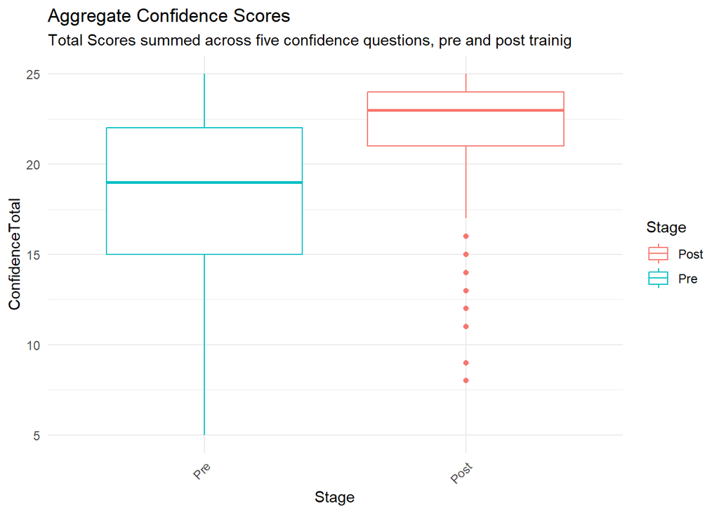

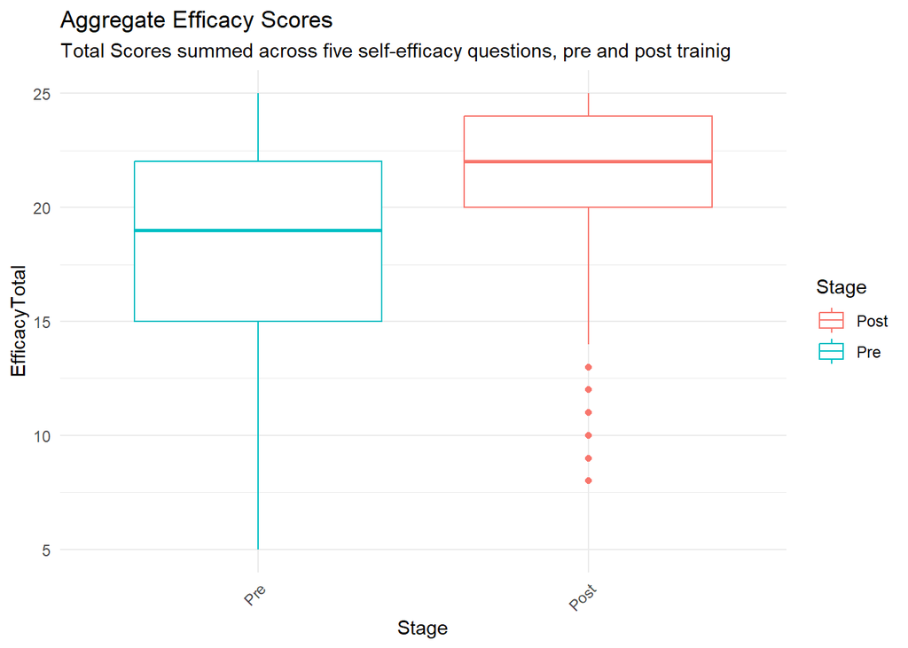

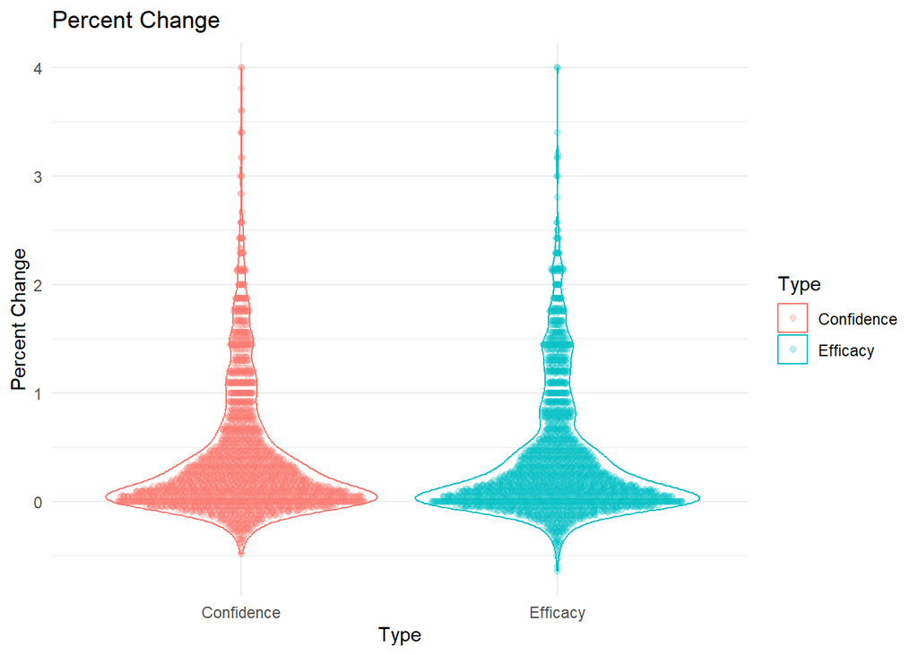

### Modeling

A series of models will be tested to determine whether there are features that are important in whether or not participants retained the job the were placed in after 6 months.